# Coursera Reproducible Research: Project 1

Jungmyun Kim

5/14/2017

## Introduction

It is now possible to collect a large amount of data about personal movement using activity monitoring devices such as a Fitbit, Nike Fuelband, or Jawbone Up. These type of devices are part of the “quantified self” movement ??? a group of enthusiasts who take measurements about themselves regularly to improve their health, to find patterns in their behavior, or because they are tech geeks. But these data remain under-utilized both because the raw data are hard to obtain and there is a lack of statistical methods and software for processing and interpreting the data.

## Load Raw data

```r
## 1. Code for reading in the dataset and/or processing the data
data_raw <- read.csv(file = "C:/Users/Device Admin/Documents/coursera/activity/activity.csv",
                    header = TRUE, sep = ",")
```

## Process/transform the data

```r
## convert data type to date format
data_raw$date <- as.POSIXct(data_raw$date, format="%Y-%m-%d")

## create columns to identify weekend and weekdays
data <- data.frame(date=data_raw$date,
                           weekday=tolower(weekdays(data_raw$date)),
                           steps=data_raw$steps,
                           interval=data_raw$interval)


data<- cbind(data,
                      daytype=ifelse(data$weekday == "토요일" | data$weekday == "일요일", "weekend", "weekday"))



## Calculate the total number of steps taken per day
sum_data <- aggregate(data$steps, by=list(data$date), FUN=sum, na.rm=TRUE)

names(sum_data) <- c("date", "steps")
```

## Plot Diagram

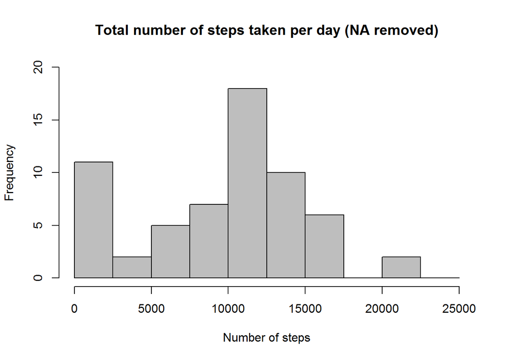

```r
## 2. Histogram of the total number of steps taken each day
hist(sum_data$steps,
     breaks=seq(from=0, to=25000, by=2500),
     col="gray",
     xlab="Number of steps",
     ylim=c(0, 20),
     main="Total number of steps taken per day (NA removed)")
```

## 3. Mean and median number of steps taken each day

```r
mean(sum_data$steps)
```

```
## [1] 9354.23
```

```r
median(sum_data$steps)
```

```
## [1] 10395
```

###### mean and median of 9354 and 10395 respectively.

## 4. Time series plot of the average number of steps taken

```r
## What is the average daily activity pattern?
mean_data <- aggregate(data$steps,
                       by=list(data$interval),
                       FUN=mean,
                       na.rm=TRUE)
names(mean_data) <- c("5min Interval", "mean")
```

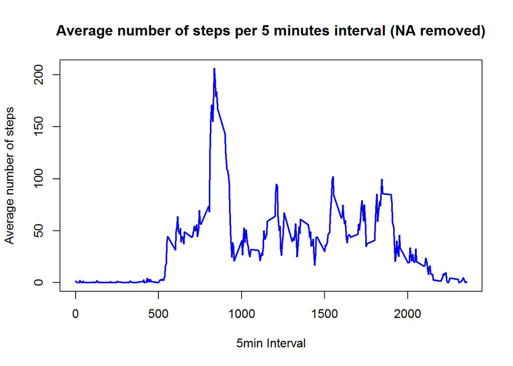

```r
##Make a time series plot (i.e. type = "l") of the 5-minute interval (x-axis) and the average number of steps taken, averaged across all days (y-axis)
plot(mean_data$"5min Interval",
     mean_data$mean,
     type="l",
     col="blue",
     lwd=2,
     xlab="5min Interval",
     ylab="Average number of steps",
     main="Average number of steps per 5 minutes interval (NA removed)")
```

## 5. The 5-minute interval that, on average, contains the maximum number of steps

```r
##Which 5-minute interval, on average across all the days in the dataset, contains the maximum number of steps?
mean_data[which(mean_data$mean == max(mean_data$mean)), 1]
```

```
## [1] 835
```

## 6. Code to describe and show a strategy for imputing missing data

```r
## 1. Calculate and report the total number of missing values in the dataset
sum(is.na(data$steps))
```

```
## [1] 2304
```

```r
##Devise a strategy for filling in all of the missing values in the dataset
naposi <- which(is.na(data$steps))
mean_vector <- rep(mean(data$steps, na.rm=TRUE), times=length(naposi))

data[naposi, "steps"] <- mean_vector

##Create a new dataset that is equal to the original dataset but with the missing data filled in.
sum_data <- aggregate(data$steps, by=list(data$date), FUN=sum, na.rm=TRUE)

names(sum_data) <- c("date", "steps")
```

## 7. Histogram of the total number of steps taken each day after missing values are imputed

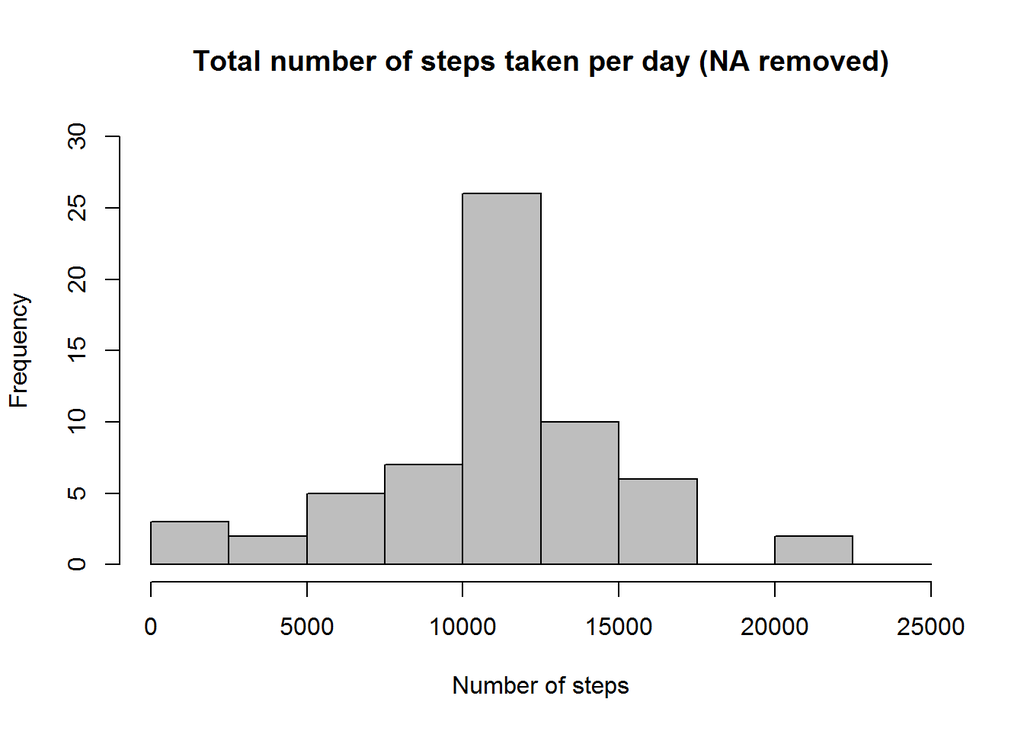

```r
##Make a histogram of the total number of steps taken each day
hist(sum_data$steps,
     breaks=seq(from=0, to=25000, by=2500),
     col="gray",
     xlab="Number of steps",
     ylim=c(0, 30),
     main="Total number of steps taken per day (NA removed)")
```

```r
##Calculate and report the mean and median total number of steps taken per day
mean(sum_data$steps)
```

```
## [1] 10766.19
```

```r
median(sum_data$steps)
```

```
## [1] 10766.19
```

###### mean and median of 10766 and 10766

###### medain didn’t change much after the replacements of NAs. MEAN has been increased 15% after the replacements of NAs.

## 8. Panel plot comparing the average number of steps taken per 5-minute interval across weekdays and weekends

```r
library(lattice)


mean_data <- aggregate(data$steps,
                       by=list(data$daytype, data$weekday, data$interval), mean)
names(mean_data) <- c("daytype", "dayofweek", "interval", "mean")
```

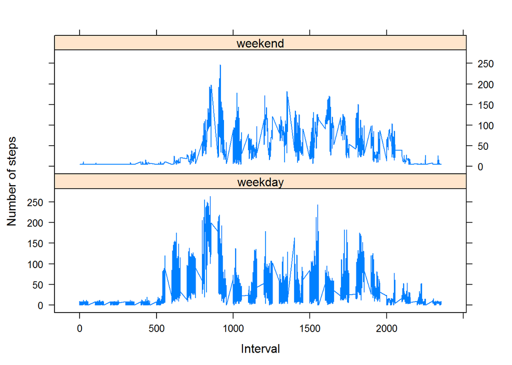

```r
xyplot(mean ~ interval | daytype, mean_data,
       type="l",
       lwd=1,
       xlab="Interval",
       ylab="Number of steps",
       layout=c(1,2))
```